# OpenPBTA: Explore a PLIER latent variable

CCDL for ALSF

2020

In this notebook, we’ll plot the differences in a single PLIER latent variable’s values between the 4 medulloblastoma molecular subgroups in our data: Group 3, Group 4, SHH and WNT.

Our objective is to learn more about using the `ggplot2` package for a common use case in life science research: visualizing the difference in values between some experimental or clinical group for a single measure.

Often when we’re working with high-throughout biological data like transcriptomic data, it takes some wrangling to get the data in a format for plotting with `ggplot2`. So we’ll cover how to do that, too.

## First, a note on tidy data

In order to use `ggplot2`, we’ll need the data in “long” or “tidy” format. `PLIER` outputs what we want to plot in what we call “wide” format.

Read more about tidy data [here](https://cran.r-project.org/web/packages/tidyr/vignettes/tidy-data.html).

To quote from Hadley Wickham’s [R for Data Science](https://r4ds.had.co.nz/):

> There are three interrelated rules which make a dataset tidy:
> - Each variable must have its own column.
> - Each observation must have its own row.
> - Each value must have its own cell.

Let’s look at a toy example.

```r
set.seed(12345)
toy_df <- data.frame(
  cbind(c("GENEA", "GENEB", "GENEC"),
        matrix(rnorm(30), ncol = 10))
)
colnames(toy_df) <- c("Gene", paste0("Sample", 1:10))
```

`toy_df` is now in “wide” format.

```r
toy_df
```

| Gene | Sample1 | Sample2 | Sample3 | Sample4 | Sample5 | Sample6 | Sample7 | Sample8 | Sample9 | Sample10 |
| --- | --- | --- | --- | --- | --- | --- | --- | --- | --- | --- |
| GENEA | 0.585528817843856 | -0.453497173462763 | 0.630098551068391 | -0.919322002474128 | 0.370627864257954 | 0.816899839520583 | 1.12071265166956 | 1.45578508247686 | -1.59770951669631 | 0.620379801298422 |
| GENEB | 0.709466017509524 | 0.605887455840394 | -0.276184105225216 | -0.116247806352002 | 0.520216457554957 | -0.886357521243213 | 0.298723699267293 | -0.644328429231302 | 1.80509751881082 | 0.612123492650849 |
| GENEC | -0.109303314681054 | -1.81795596770373 | -0.284159743943371 | 1.81731204370422 | -0.750531994502331 | -0.331577589942552 | 0.779621924555324 | -1.55313740522969 | -0.481647363694637 | -0.162310976918126 |

Let’s get it into “long” format.

```r
toy_long_df <- tidyr::pivot_longer(toy_df,
                                   # The data is in every column except the one
                                   # named "Gene"
                                   cols = -Gene,
                                   # What will we call the column of the old df
                                   # column names?
                                   names_to = "Sample",
                                   # What will we call the column of values
                                   # from the old df?
                                   values_to = "Expression")

toy_long_df
```

| Gene | Sample | Expression |
| --- | --- | --- |
| GENEA | Sample1 | 0.585528817843856 |
| GENEA | Sample2 | -0.453497173462763 |
| GENEA | Sample3 | 0.630098551068391 |
| GENEA | Sample4 | -0.919322002474128 |
| GENEA | Sample5 | 0.370627864257954 |
| GENEA | Sample6 | 0.816899839520583 |
| GENEA | Sample7 | 1.12071265166956 |
| GENEA | Sample8 | 1.45578508247686 |
| GENEA | Sample9 | -1.59770951669631 |
| GENEA | Sample10 | 0.620379801298422 |

[output cut: 20 more lines]

Let’s remove these toy examples from the workspace.

```r
rm(toy_df, toy_long_df)
```

## Set up

### Libraries

```r
library(tidyverse)
# Package for annotation of statistical significance on plots
library(ggsignif)
```

### Directories and files

#### Directories

```r
# Directory that holds the metadata
data_dir <- file.path("data", "open-pbta", "processed")
# Directory that holds the PLIER output
models_dir <- "models"
# Directory to hold the plot output - create if it doesn't exist yet
plots_dir <- "plots"
if (!dir.exists(plots_dir)) {
  dir.create(plots_dir, recursive = TRUE)
}
```

#### Input

```r
histologies_file <- file.path(data_dir, "pbta-histologies-stranded-rnaseq.tsv")
plier_file <- file.path(models_dir, "pbta-medulloblastoma-plier.RDS")
```

#### Output

```r
boxplot_png <- file.path(plots_dir, "medulloblastoma_LV57_boxplot.png")
```

## Read in data and prepare for plotting

### Sample metadata

```r
histologies_df <- read_tsv(histologies_file)
```

### PLIER results

```r
# Read in the PLIER results
plier_results <- read_rds(plier_file)
```

For biological discovery, we are often most interested in the latent variables that have some kind of association with an input gene set or pathway. We can use the FDR values in the summary data frame to filter to only the latent variables with a significant association (and their associated gene sets).

```r
# Filter to LV-pathway relationships with FDR < 0.05
sig_summary_df <- plier_results$summary %>%
  dplyr::filter(FDR < 0.05)
sig_summary_df
```

| pathway | LV index | AUC | p-value | FDR |
| --- | --- | --- | --- | --- |
| KEGG_LYSOSOME | 2 | 0.6365064 | 6.659643e-03 | 1.221733e-02 |
| REACTOME_MITOCHONDRIAL_PROTEIN_IMPORT | 3 | 0.9357098 | 5.744474e-07 | 3.959030e-06 |
| REACTOME_DESTABILIZATION_OF_MRNA_BY_AUF1_HNRNP_D0 | 3 | 0.9601020 | 3.086543e-08 | 3.422037e-07 |
| REACTOME_HIV_INFECTION | 3 | 0.7956418 | 2.340119e-11 | 6.630336e-10 |
| REACTOME_METABOLISM_OF_AMINO_ACIDS_AND_DERIVATIVES | 3 | 0.7353064 | 5.739374e-07 | 3.959030e-06 |
| KEGG_OXIDATIVE_PHOSPHORYLATION | 3 | 0.9171252 | 2.060444e-12 | 6.567666e-11 |
| REACTOME_GLUCOSE_METABOLISM | 3 | 0.7877159 | 1.923334e-04 | 5.770003e-04 |
| KEGG_PROTEASOME | 3 | 0.8048142 | 6.654370e-04 | 1.616061e-03 |
| KEGG_PURINE_METABOLISM | 3 | 0.6498342 | 2.684309e-03 | 5.565031e-03 |
| REACTOME_SIGNALING_BY_WNT | 3 | 0.9097589 | 6.454524e-08 | 5.309367e-07 |

[output cut: 90 more lines]

```r
# We only want a single instance of each LV index
sig_index <- as.integer(unique(sig_summary_df$`LV index`))
```

```r
# Get the LV by sample matrix from the PLIER results and subset it to only those
# LVs with an FDR < 0.05 (at least one pathway)
b_matrix <- plier_results$B
sig_b_matrix <- b_matrix[sig_index, ]

# Create a data frame and add a column with LV identifiers
sig_b_wide <- data.frame(sig_b_matrix) %>%
  tibble::rownames_to_column(var = "LV")
```

#### Tidy

Let’s look at what format this is in currently.

```r
sig_b_wide
```

| LV | BS_09Z7TC35 | BS_1AYRM596 | BS_1BWP5MCT | BS_1QXEC43H | BS_1TWCV047 | BS_2SFTWNVE | BS_2Z1MKS84 | BS_3BDAG9YN | BS_3F5PR9GS | BS_3MYEMXPQ | BS_3NWQXPQV | BS_3V3KE3VT | BS_44A3ES23 | BS_4CP4T22V | BS_4D9DD103 | BS_4PH1MBGR | BS_4W68NV3M | BS_5PJCHF6V | BS_5VQP0E6K | BS_61E80SD6 | BS_77317DY4 | BS_7C40TRCY | BS_7FWZ518S | BS_7XQRH69M | BS_81SP2HX4 | BS_8GW1TMV2 | BS_8T7DZV2F | BS_9M5XJ10G | BS_9NJHQE9F | … |
| --- | --- | --- | --- | --- | --- | --- | --- | --- | --- | --- | --- | --- | --- | --- | --- | --- | --- | --- | --- | --- | --- | --- | --- | --- | --- | --- | --- | --- | --- | --- |
| 2,KEGG_LYSOSOME | -0.589605248 | 0.311457825 | -0.85328041 | 0.08090672 | -0.420891575 | 0.06347691 | 0.49236755 | 0.4044434 | -0.95719411 | 0.10194132 | 1.39401340 | -0.80636999 | -1.0399039 | 0.58023344 | 0.8080823495 | 0.7610520151 | -0.08958527 | 1.0139655572 | 0.137178961 | 0.29726154 | 0.72079126 | -0.61325456 | 0.26054611 | -0.54071554 | -0.75217083 | -0.19022883 | 0.01513752 | 0.72132576 | -0.13668667 | … |
| 3,KEGG_OXIDATIVE_PHOSPHORYLATION | 0.776323613 | -0.224744733 | -1.54052417 | 0.87426434 | -0.673716615 | -0.68131730 | 0.06047078 | 1.5942179 | -1.03317459 | -0.74242376 | -0.62252072 | -0.29464925 | -1.7321312 | -1.03681619 | 0.0433894366 | -0.4847138530 | -1.41116849 | -0.9848804901 | -0.810540205 | -0.68957221 | -1.86907878 | -0.64905104 | -0.21743201 | -0.16170194 | 1.13747101 | 0.29677673 | 0.35712448 | -0.40088621 | 0.36060179 | … |
| 8,REACTOME_GENERIC_TRANSCRIPTION_PATHWAY | -0.192492652 | 0.844505262 | 0.43735196 | -0.09718849 | 0.584123021 | 0.16209147 | -0.17585164 | -0.1134642 | 0.73774614 | 0.24539230 | -0.20206542 | -1.04634234 | -0.9548086 | -0.53724221 | 0.0330572148 | -0.4014171363 | 0.71194597 | -0.3422838982 | -0.364308240 | 0.30137910 | 0.04583303 | 0.49163615 | -0.18591606 | -0.33309904 | 0.89584329 | -0.33620863 | -0.27836134 | 0.03034453 | 0.03651313 | … |
| 11,MIPS_SPLICEOSOME | -0.131517153 | 0.641954140 | 0.48410365 | -1.69603797 | -0.577928683 | -0.01245898 | -1.07499797 | 1.3945839 | 0.53393441 | 0.64120844 | 0.25575010 | -0.11204494 | -0.9056187 | 0.82437163 | -2.0250573560 | -0.4837054047 | -1.66767647 | 0.2467401396 | 0.173963072 | 0.04722657 | -2.05278255 | 0.22991861 | 0.35826859 | -0.11809897 | 0.79677450 | 1.34197790 | 1.00349455 | -0.17977609 | 0.86948585 | … |
| 12,KEGG_LYSOSOME | 0.777777547 | -0.316624759 | -0.93222692 | -0.24388464 | -0.022822574 | -0.52708086 | 0.52554681 | 1.9173576 | -1.29881647 | -0.65176608 | 0.41609261 | 1.34091978 | 0.7616261 | -0.03042964 | 0.9412903517 | 0.0223375629 | 0.51518018 | -0.1052614304 | -0.149527483 | -0.65058084 | 0.29370179 | -0.57873382 | -0.66970932 | -0.43750679 | -0.27078043 | 0.15887058 | 1.02689850 | -0.39964332 | -0.01997265 | … |
| 13,PID_HIF1_TFPATHWAY | -0.004817585 | 0.046060816 | 0.14503297 | -0.53530906 | 0.039530777 | -0.24109752 | -0.11997212 | 1.0236632 | -0.62246688 | -0.03725765 | 0.27206973 | -0.41138074 | -0.2072299 | 0.30142936 | -0.2472654085 | 0.2397808293 | -0.15657706 | 0.3113268716 | -0.581367882 | -0.05206609 | -0.01827228 | -0.42743552 | 0.21545066 | -0.59542615 | -0.88628897 | 0.02121519 | 1.12581123 | 0.64685776 | 0.14496659 | … |
| 15,KEGG_FOCAL_ADHESION | 0.216513676 | 0.878243172 | -1.14169490 | 0.91645084 | -0.284764173 | -0.50925792 | 0.20722079 | 1.6787574 | -0.50743478 | 0.13352430 | -1.13410137 | 0.17077797 | 1.1789547 | -0.25064685 | -0.2470470186 | 0.5574441153 | 0.74460153 | -0.4655095102 | -0.333598156 | -0.10565932 | 0.01327307 | 0.02947169 | -0.61538502 | 0.24804144 | 0.05876160 | 0.32746770 | 2.15108613 | -0.27527118 | -0.37692618 | … |
| 16,REACTOME_POST_TRANSLATIONAL_PROTEIN_MODIFICATION | -0.400284466 | 0.104326210 | -0.60374935 | 0.33272949 | -0.367271913 | -0.22086729 | 2.06012675 | -0.2402412 | -0.52614331 | -0.62871241 | -0.44153657 | -0.38826434 | -0.5179407 | -0.57872213 | 3.1569955248 | -0.4490012162 | -0.05183614 | -0.3206082827 | 2.614081762 | -0.33739263 | 2.65664423 | -0.26747677 | -0.32753582 | -0.48412511 | -0.01615174 | -0.13202125 | 0.53243546 | -0.21050998 | -0.36527161 | … |
| 17,MIPS_SPLICEOSOME | 1.130363361 | -0.017854535 | 0.32713054 | 0.21054839 | 0.334081338 | -0.11291563 | 0.08294378 | -0.3424019 | 0.21318280 | -0.41433956 | 0.87980455 | 0.10610504 | 1.1877484 | 0.17696625 | 0.5845019440 | 0.1532830287 | 0.79781722 | -0.3811728770 | -0.365779832 | -0.63179999 | 1.16010695 | 0.02324941 | -0.11249642 | -0.21584917 | 0.19672890 | -0.68869891 | -0.59978015 | 0.04776875 | -0.29283445 | … |
| 18,KEGG_AXON_GUIDANCE | -1.184069088 | -0.090529432 | -2.68104268 | -0.03016834 | -0.180943684 | 0.27721891 | -0.01879261 | -2.0604418 | 0.82362188 | 0.11824436 | -0.54843515 | 0.18528898 | 0.7324150 | 0.07795305 | -0.5514844925 | 0.4802626383 | 0.21577335 | 0.5544320267 | 0.003855971 | 0.54505804 | -0.42605259 | 1.14940832 | 0.29627522 | 1.00049184 | 0.42258825 | -0.06740197 | -1.86525612 | 0.15889768 | -0.72436812 | … |

[output cut: 17 more lines]

We want this in long format for plotting. We’ll use `tidyr::pivot_longer` to do this just like in the toy example above.

```r
sig_b_df <- tidyr::pivot_longer(sig_b_wide,
                                cols = starts_with("BS_"),
                                names_to = "Kids_First_Biospecimen_ID",
                                values_to = "LV_estimate")
head(sig_b_df)
```

| LV | Kids_First_Biospecimen_ID | LV_estimate |
| --- | --- | --- |
| 2,KEGG_LYSOSOME | BS_09Z7TC35 | -0.58960525 |
| 2,KEGG_LYSOSOME | BS_1AYRM596 | 0.31145783 |
| 2,KEGG_LYSOSOME | BS_1BWP5MCT | -0.85328041 |
| 2,KEGG_LYSOSOME | BS_1QXEC43H | 0.08090672 |
| 2,KEGG_LYSOSOME | BS_1TWCV047 | -0.42089158 |
| 2,KEGG_LYSOSOME | BS_2SFTWNVE | 0.06347691 |

Right now the `LV` column has values that contain two pieces of information: the LV index and the pathway that the LV has been named for.

*Remember, just because a LV is named for a single pathway, that doesn’t mean that that is the only input pathway that is significantly associated with that latent variable - always check `summary`!*

Now let’s add relevant metadata to the data frame so we can use that for plotting.

```r
# Create a data frame that only has the biospecimen identifiers and the
# molecular subtype labels
subtype_df <- histologies_df %>%
  select(Kids_First_Biospecimen_ID,
         molecular_subtype)

# Add the subtype labels to the LV estimates
sig_b_df <- inner_join(x = sig_b_df,
                       y = subtype_df,
                       by = "Kids_First_Biospecimen_ID")
```

## Plotting

We’ll plot LV57; this is the latent variable that we looked at the loadings for in the previous notebook.

```r
# PLIER names certain latent variables based on their association with input
# gene sets
lv_to_plot <- "57,SVM Macrophages M2"
# For plotting, subset only to the rows corresponding to this latent variable
lv_plot_df <- sig_b_df %>%
  filter(LV == lv_to_plot)
```

### Boxplot and customization

Let’s start by making a simple boxplot.

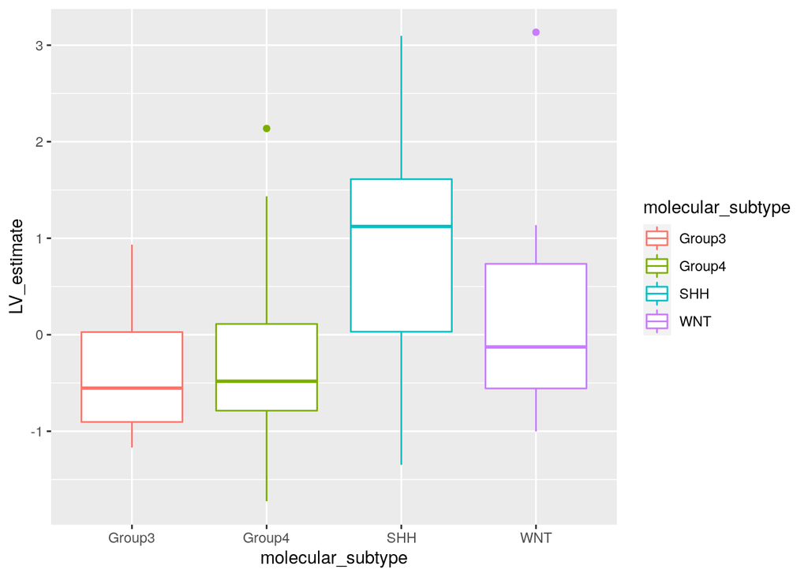

```r
# Make a boxplot where samples are grouped by molecular subtype
ggplot(lv_plot_df,
       aes(x = molecular_subtype,
           y = LV_estimate,
           group = molecular_subtype,
           colour = molecular_subtype)) +
  geom_boxplot()
```

It can often be helpful to visualize individual samples.

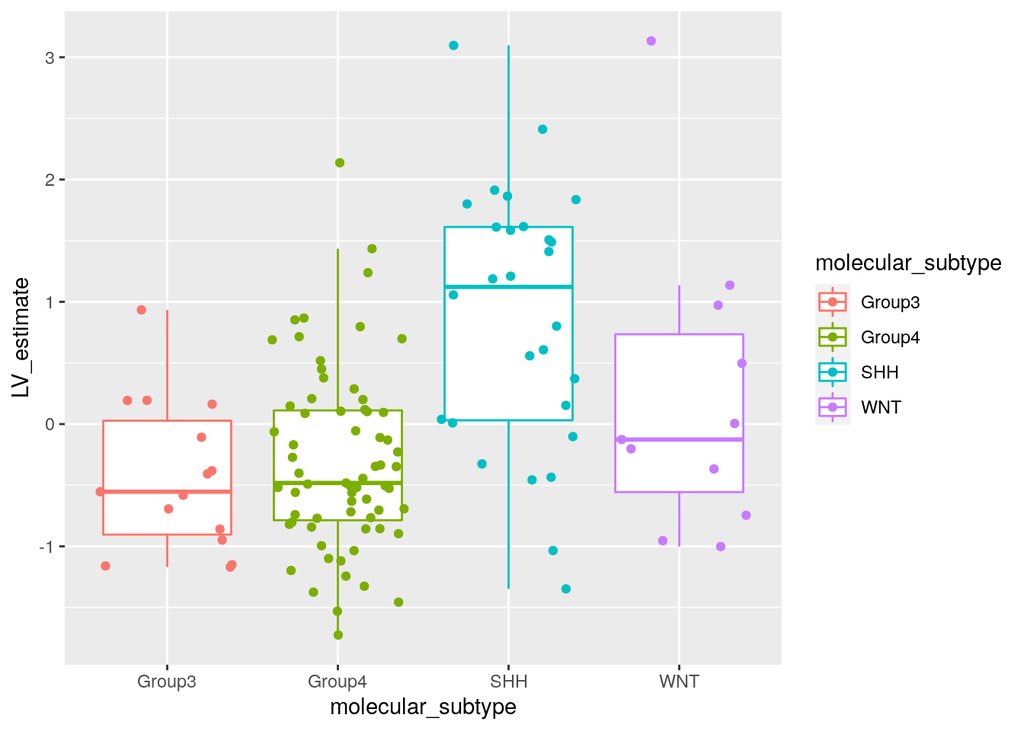

```r
# Add individual points with geom_jitter()
ggplot(lv_plot_df,
       aes(x = molecular_subtype,
           y = LV_estimate,
           group = molecular_subtype,
           colour = molecular_subtype)) +
  geom_boxplot(outlier.shape = NA) +
  geom_jitter()
```

We’re able to globally adjust the aesthetics of the jitter points.

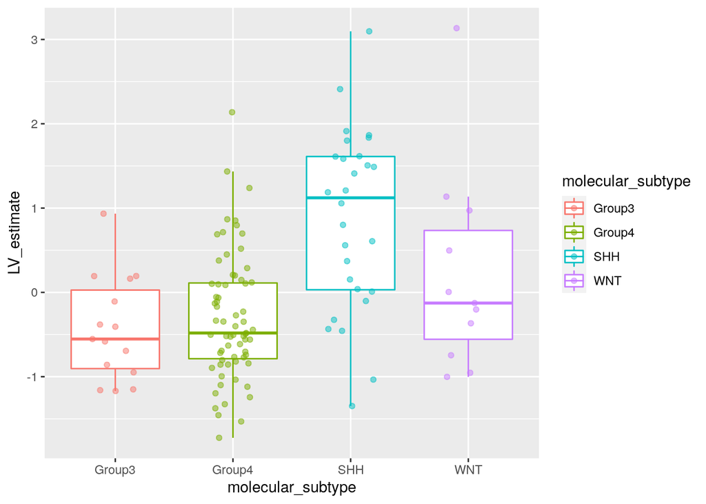

```r
# Improve the aesthetics of the points
ggplot(lv_plot_df,
       aes(x = molecular_subtype,
           y = LV_estimate,
           group = molecular_subtype,
           colour = molecular_subtype)) +
  geom_boxplot(outlier.shape = NA) +
  geom_jitter(width = 0.2, alpha = 0.5)
```

Add a built-in `ggplot2` theme.

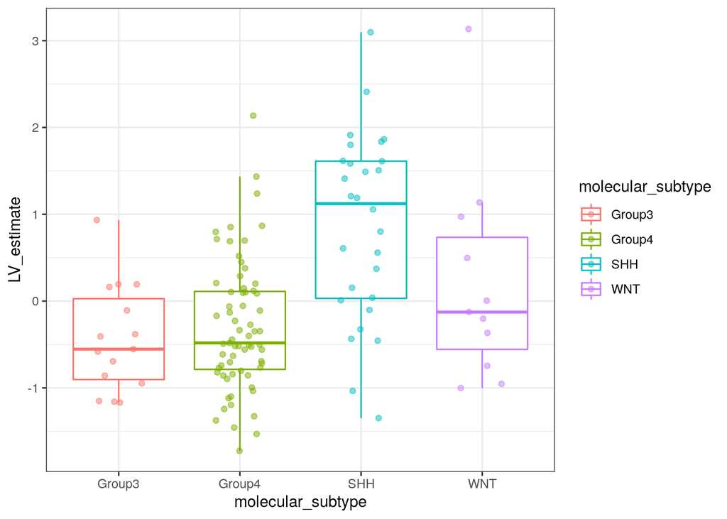

```r
# Use @jaclyn-taroni's favorite theme :)
ggplot(lv_plot_df,
       aes(x = molecular_subtype,
           y = LV_estimate,
           group = molecular_subtype,
           colour = molecular_subtype)) +
  geom_boxplot(outlier.shape = NA) +
  geom_jitter(width = 0.2, alpha = 0.5) +
  theme_bw()
```

Use the same color palette we used in the UMAP plot earlier in the module.

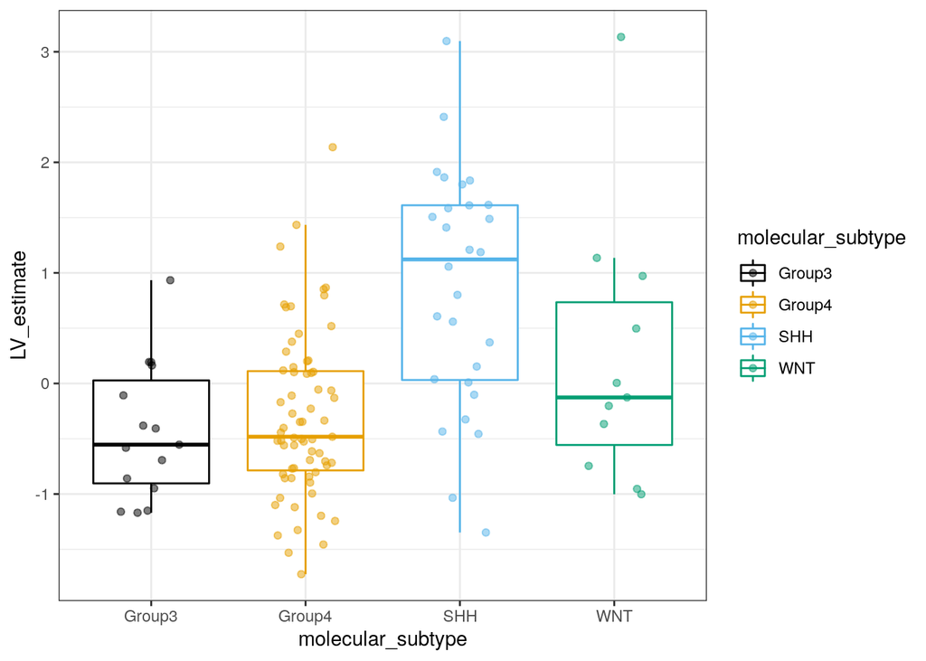

```r
# Add "Okabe-Ito" color scheme
ggplot(lv_plot_df,
       aes(x = molecular_subtype,
           y = LV_estimate,
           group = molecular_subtype,
           colour = molecular_subtype)) +
  geom_boxplot(outlier.shape = NA) +
  geom_jitter(width = 0.2, alpha = 0.5) +
  theme_bw() +
  scale_color_manual(values = unname(palette.colors(palette = "Okabe-Ito")))
```

Add a title to the plot.

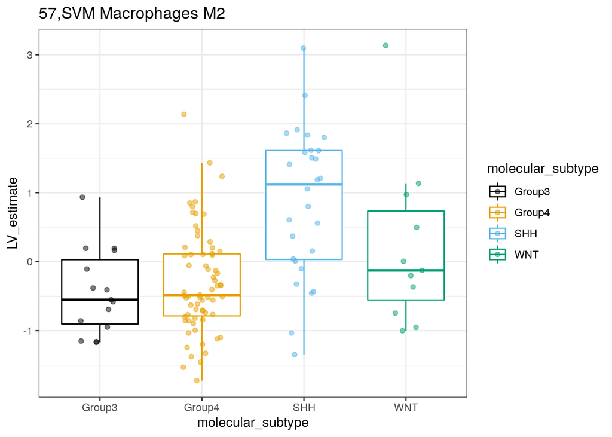

```r
# Use labs() to add a title
ggplot(lv_plot_df,
       aes(x = molecular_subtype,
           y = LV_estimate,
           group = molecular_subtype,
           colour = molecular_subtype)) +
  geom_boxplot(outlier.shape = NA) +
  geom_jitter(width = 0.2, alpha = 0.5) +
  theme_bw() +
  scale_color_manual(values = unname(palette.colors(palette = "Okabe-Ito"))) +
  labs(title = lv_to_plot)
```

Center the title and make it bigger and in bold.

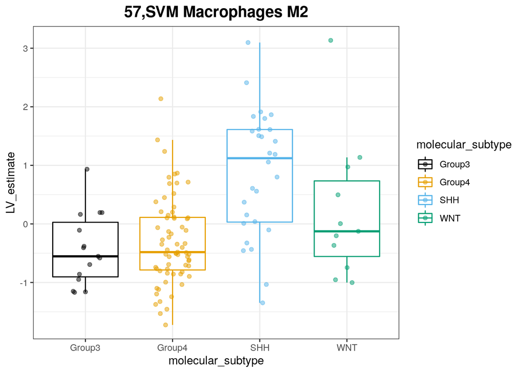

```r
# Use theme() to improve the way the title looks
ggplot(lv_plot_df,
       aes(x = molecular_subtype,
           y = LV_estimate,
           group = molecular_subtype,
           colour = molecular_subtype)) +
  geom_boxplot(outlier.shape = NA) +
  geom_jitter(width = 0.2, alpha = 0.5) +
  theme_bw() +
  scale_color_manual(values = unname(palette.colors(palette = "Okabe-Ito"))) +
  labs(title = lv_to_plot) +
  theme(plot.title = element_text(size = 15,
                                  face = "bold",
                                  hjust = 0.5))
```

Use the next chunks to further customize your plot. We might suggest starting with the x- and y-axis labels.

```r
?labs
```

### Adding p-values to a plot

R is great for analyzing genomic data and for publication ready visualizations, but as language for statistical computing, it’s also great for statistical analysis!

Let’s start by performing a pairwise Wilcoxon rank sum test. This is also sometimes called a Mann-Whitney U test. It is a non-parametric test of the null hypothesis that two groups are from the same population or that the medians of the two groups are identical. *Pairwise* means we will test all pairs of groups.

We can put that information onto the plot with the `ggsignif` package.

```r
pairwise.wilcox.test(x = lv_plot_df$LV_estimate,
                     g = lv_plot_df$molecular_subtype,
                     # Because we're performing multiple tests, we should
                     # adjust the p-values
                     p.adjust.method = "bonferroni")
```

```
    Pairwise comparisons using Wilcoxon rank sum test with continuity correction

data:  lv_plot_df$LV_estimate and lv_plot_df$molecular_subtype

       Group3  Group4  SHH
Group4 1.00000 -       -
SHH    0.00071 9e-06   -
WNT    0.89067 1.00000 0.30052

P value adjustment method: bonferroni
```

And now we’re ready to add the adjusted p-values to the plot with `ggsignif::geom_signif()`.

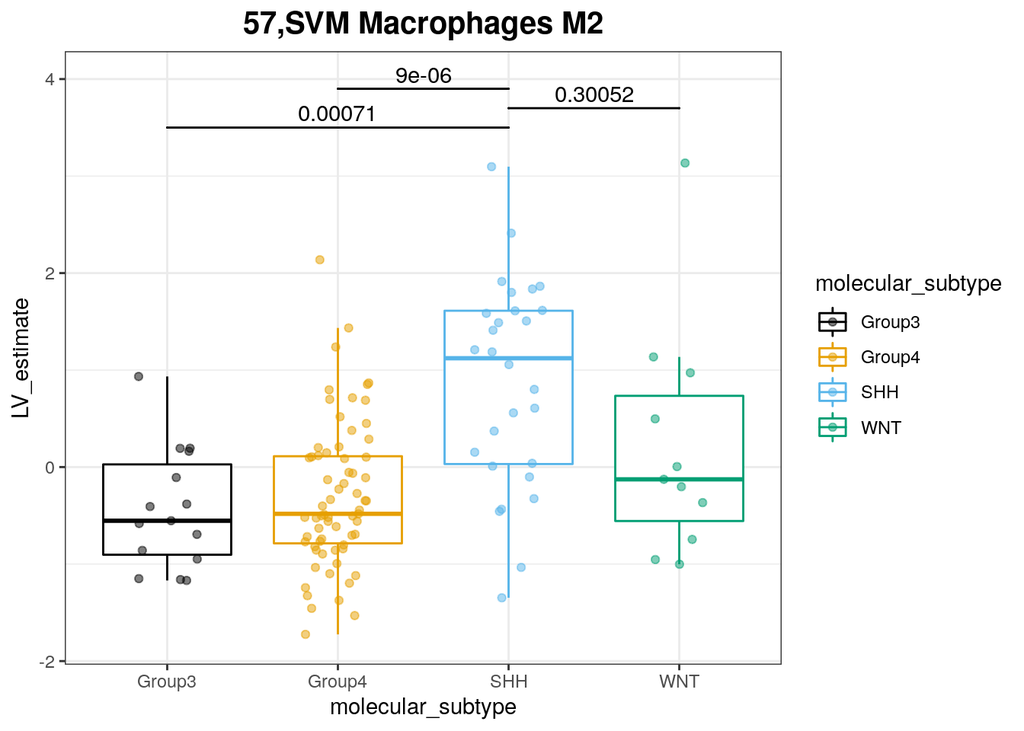

```r
# Add the adjusted p-values
ggplot(lv_plot_df,
       aes(x = molecular_subtype,
           y = LV_estimate,
           group = molecular_subtype,
           colour = molecular_subtype)) +
  geom_boxplot(outlier.shape = NA) +
  geom_jitter(width = 0.2, alpha = 0.5) +
  theme_bw() +
  scale_color_manual(values = unname(palette.colors(palette = "Okabe-Ito"))) +
  labs(title = lv_to_plot) +
  theme(plot.title = element_text(size = 15,
                                  face = "bold",
                                  hjust = 0.5)) +
  # This is to make room for the labels - these values are highly specific to
  # this plot!
  ylim(c(-1.75, 4)) +
  # Note this is highly specific to this plot!
  # This can not be applied to any other plot without significant modification!
  geom_signif(y_position = c(3.5, 3.9, 3.7),
              xmin = c("Group3", "Group4", "SHH"),
              xmax  = c("SHH", "SHH", "WNT"),
              annotations = c("0.00071", "9e-06", "0.30052"),
              tip_length = 0,
              color = "#000000")
```

Save this final plot to file.

```r
ggsave(filename = boxplot_png)
```